# R Notebook

```r
knitr::opts_chunk$set(echo = TRUE , warning = FALSE, message = FALSE)
```

```r
library(ggplot2)
library(car)
library(caret)
library(patchwork)
library(pROC)
```

```r
setwd("C:/Users/patel/OneDrive/Documents/DSC423/project/Dataset")
data <- read.csv("indian_liver_patient.csv", header = TRUE, sep = ",")
head(data)
```

|  | Age | Gender | Total_Bilirubin | Direct_Bilirubin | Alkaline_Phosphotase | Alamine_Aminotransferase | Aspartate_Aminotransferase | Total_Protiens | Albumin | Albumin_and_Globulin_Ratio | Dataset |
| --- | --- | --- | --- | --- | --- | --- | --- | --- | --- | --- | --- |
| 1 | 65 | Female | 0.7 | 0.1 | 187 | 16 | 18 | 6.8 | 3.3 | 0.90 | 1 |
| 2 | 62 | Male | 10.9 | 5.5 | 699 | 64 | 100 | 7.5 | 3.2 | 0.74 | 1 |
| 3 | 62 | Male | 7.3 | 4.1 | 490 | 60 | 68 | 7.0 | 3.3 | 0.89 | 1 |
| 4 | 58 | Male | 1.0 | 0.4 | 182 | 14 | 20 | 6.8 | 3.4 | 1.00 | 1 |
| 5 | 72 | Male | 3.9 | 2.0 | 195 | 27 | 59 | 7.3 | 2.4 | 0.40 | 1 |
| 6 | 46 | Male | 1.8 | 0.7 | 208 | 19 | 14 | 7.6 | 4.4 | 1.30 | 1 |

```r
summary(data)
```

```
      Age           Gender          Total_Bilirubin  Direct_Bilirubin Alkaline_Phosphotase
 Min.   : 4.00   Length:583         Min.   : 0.400   Min.   : 0.100   Min.   :  63.0
 1st Qu.:33.00   Class :character   1st Qu.: 0.800   1st Qu.: 0.200   1st Qu.: 175.5
 Median :45.00   Mode  :character   Median : 1.000   Median : 0.300   Median : 208.0
 Mean   :44.75                      Mean   : 3.299   Mean   : 1.486   Mean   : 290.6
 3rd Qu.:58.00                      3rd Qu.: 2.600   3rd Qu.: 1.300   3rd Qu.: 298.0
 Max.   :90.00                      Max.   :75.000   Max.   :19.700   Max.   :2110.0

 Alamine_Aminotransferase Aspartate_Aminotransferase Total_Protiens     Albumin
 Min.   :  10.00          Min.   :  10.0             Min.   :2.700   Min.   :0.900
 1st Qu.:  23.00          1st Qu.:  25.0             1st Qu.:5.800   1st Qu.:2.600
 Median :  35.00          Median :  42.0             Median :6.600   Median :3.100
 Mean   :  80.71          Mean   : 109.9             Mean   :6.483   Mean   :3.142
 3rd Qu.:  60.50          3rd Qu.:  87.0             3rd Qu.:7.200   3rd Qu.:3.800
 Max.   :2000.00          Max.   :4929.0             Max.   :9.600   Max.   :5.500

 Albumin_and_Globulin_Ratio    Dataset
 Min.   :0.3000             Min.   :1.000
 1st Qu.:0.7000             1st Qu.:1.000
 Median :0.9300             Median :1.000
 Mean   :0.9471             Mean   :1.286
 3rd Qu.:1.1000             3rd Qu.:2.000
 Max.   :2.8000             Max.   :2.000
 NA's   :4
```

**Let’s clean the missing values from the dataset.**

```r
#Check for missing values.
missing_data <- sum(is.na(data))
missing_data
```

```
[1] 4
```

```r
# Removing all the missing values.
data = na.omit(data)
sum(is.na(data))
```

```
[1] 0
```

```r
# Changing the name of Target variable.
data$Dataset <- ifelse(data$Dataset == 1, 1, 0)
names(data)[names(data) == "Dataset"] <- "Target"
```

```r
#Converting Target variable to factor
data$Target <- factor(data$Target, levels = c(0, 1), labels = c("Class0", "Class1"))
str(data)
```

```
'data.frame':   579 obs. of  11 variables:
 $ Age                       : int  65 62 62 58 72 46 26 29 17 55 ...
 $ Gender                    : chr  "Female" "Male" "Male" "Male" ...
 $ Total_Bilirubin           : num  0.7 10.9 7.3 1 3.9 1.8 0.9 0.9 0.9 0.7 ...
 $ Direct_Bilirubin          : num  0.1 5.5 4.1 0.4 2 0.7 0.2 0.3 0.3 0.2 ...
 $ Alkaline_Phosphotase      : int  187 699 490 182 195 208 154 202 202 290 ...
 $ Alamine_Aminotransferase  : int  16 64 60 14 27 19 16 14 22 53 ...
 $ Aspartate_Aminotransferase: int  18 100 68 20 59 14 12 11 19 58 ...
 $ Total_Protiens            : num  6.8 7.5 7 6.8 7.3 7.6 7 6.7 7.4 6.8 ...
 $ Albumin                   : num  3.3 3.2 3.3 3.4 2.4 4.4 3.5 3.6 4.1 3.4 ...
 $ Albumin_and_Globulin_Ratio: num  0.9 0.74 0.89 1 0.4 1.3 1 1.1 1.2 1 ...
 $ Target                    : Factor w/ 2 levels "Class0","Class1": 2 2 2 2 2 2 2 2 1 2 ...
 - attr(*, "na.action")= 'omit' Named int [1:4] 210 242 254 313
  ..- attr(*, "names")= chr [1:4] "210" "242" "254" "313"
```

## Data Visualizations.

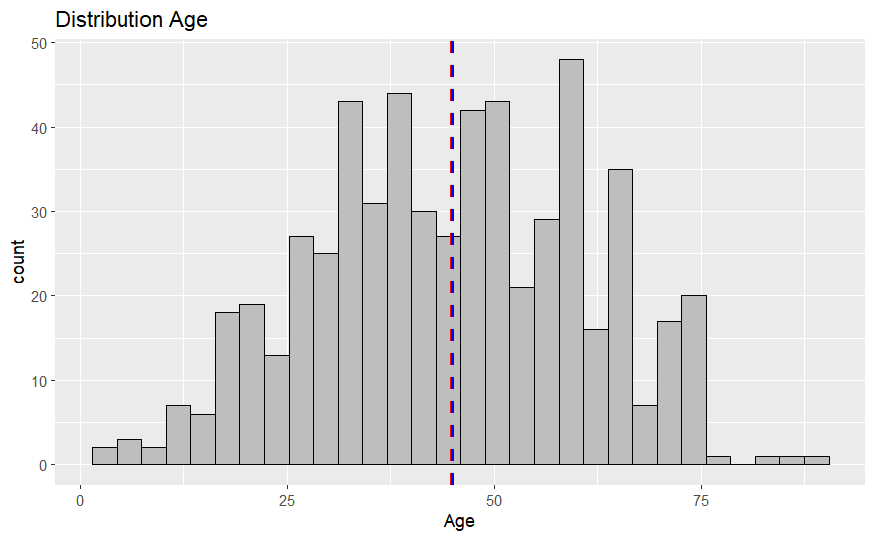

```r
ggplot(data, aes(x=Age)) + geom_histogram(fill = "grey",color = "black")+
  labs(
    title = "Distribution Age",
    )+
  geom_vline(xintercept = mean(data$Age), color = "red", linetype = "dashed", size = 1)+
  geom_vline(xintercept = median(data$Age), color = "blue", linetype = "dashed", size = 1)
```

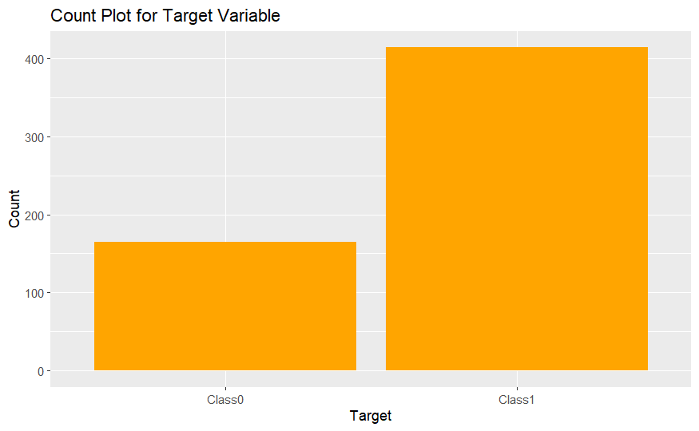

```r
ggplot(data, aes(x = Target)) +
  geom_bar(fill = "orange") +
  labs(title = "Count Plot for Target Variable", x = "Target", y = "Count")
```

```r
numerical_features <- names(data)[sapply(data, is.numeric)]
plot_list <- list()

for (feature in numerical_features) {
  p <- ggplot(data, aes_string(x = feature)) +
    geom_histogram(bins = 30, fill="grey", color="black") +
    labs(title = paste("Histogram of", feature)) +
    geom_vline(xintercept = mean(data[[feature]], na.rm = TRUE), color = "red", linetype = "dashed", size = 1) +
    geom_vline(xintercept = median(data[[feature]], na.rm = TRUE), color = "blue", linetype = "dashed", size = 1)

  plot_list[[feature]] <- p
}

# Combine the plots
plot_grid <- wrap_plots(plot_list, ncol = 3)  # Adjust ncol as needed
```

[output not shown]

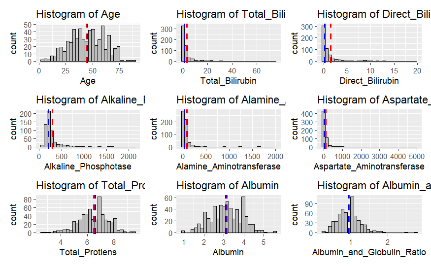

```r
# Plot the grid
plot_grid
```

This dataset appears to represent a population where the majority have normal levels for the parameters considered, especially concerning liver functions. However, there are certainly individuals with values outside the typical range who might be at risk for certain health conditions, particularly liver-related ones.

```r
numerical_features <- names(data)[sapply(data, is.numeric)]
plot_list <- list()

for (feature in numerical_features) {
  p <- ggplot(data, aes_string(x = "Target", y = feature)) +
    geom_boxplot(fill="grey") +
    labs(title = paste("Boxplot of", feature, "by Dataset"))

  plot_list[[feature]] <- p
}

# Combine the plots into a single plot object
plot_grid <- wrap_plots(plot_list, ncol = 3)  # Adjust the number of columns as necessary
```

[output not shown]

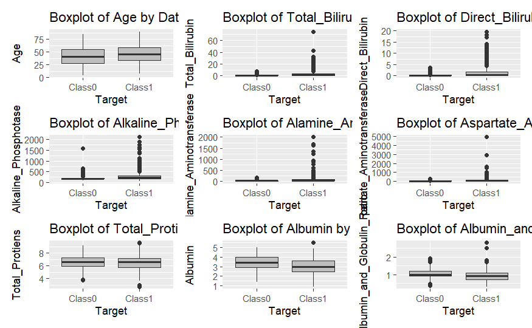

```r
# Display the grid of plots
plot_grid
```

These boxplots represent various medical features, categorized by a binary “Target.” Both groups exhibit similar distributions for many features. However, Group 1 consistently shows higher values and more outliers for liver-related metrics like bilirubin levels and aminotransferases, suggesting possible liver issues. While both groups have comparable distributions for other metrics like age and protein levels, the presence of outliers, particularly in Group 1, might indicate severe medical conditions or data anomalies. The data distinctions hint at the potential for classifying individuals based on these medical attributes.

```r
# # Load necessary libraries
# library(ggplot2)
# library(patchwork)

# Define the variables for which to plot densities
variables_to_plot <- c("Age", "Total_Bilirubin", "Direct_Bilirubin", "Alkaline_Phosphotase",
                       "Alamine_Aminotransferase", "Aspartate_Aminotransferase", "Total_Protiens",
                       "Albumin", "Albumin_and_Globulin_Ratio")

# # Apply log transformation to the variables as specified
# data$Total_Bilirubin <- log(data$Total_Bilirubin)
# data$Direct_Bilirubin <- log(data$Direct_Bilirubin)
# data$Alkaline_Phosphotase <- log(data$Alkaline_Phosphotase)
# data$Alamine_Aminotransferase <- log(data$Alamine_Aminotransferase)
# data$Aspartate_Aminotransferase <- log(data$Aspartate_Aminotransferase)

# Create a list to store the plots
plot_list <- list()

# Loop through the variables and create a density plot for each
for (variable in variables_to_plot) {
  p <- ggplot(data, aes_string(x = variable)) +
    geom_density(fill = "blue", alpha = 0.5) +
    labs(title = paste("Density plot of", variable))

  plot_list[[variable]] <- p
}

# Combine the plots into a grid
plot_grid <- wrap_plots(plot_list, ncol = 3)  # Adjust ncol as necessary
```

[output not shown]

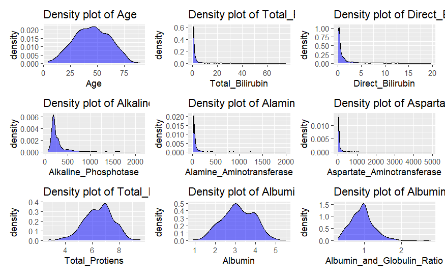

```r
# Display the grid of plots
plot_grid
```

The density plots display the distribution of various clinical metrics for a population. Age is centered around middle adulthood, with most biochemical markers showing a right-skewed distribution, indicating a few individuals with high values. Total proteins and albumin have a near-normal distribution, suggesting typical ranges for the majority, while the albumin and globulin ratio is mostly below 1. Overall, these plots suggest a range of health statuses, with most individuals within normal bounds but some exhibiting potential clinical abnormalities.

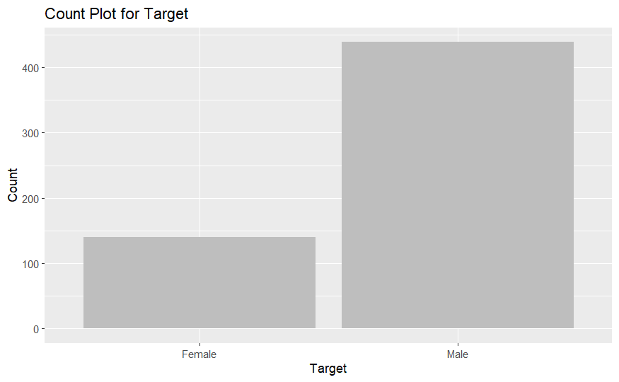

```r
ggplot(data, aes(x = Gender)) +
  geom_bar(fill = "grey") +
  labs(title = "Count Plot for Target", x = "Target", y = "Count")
```

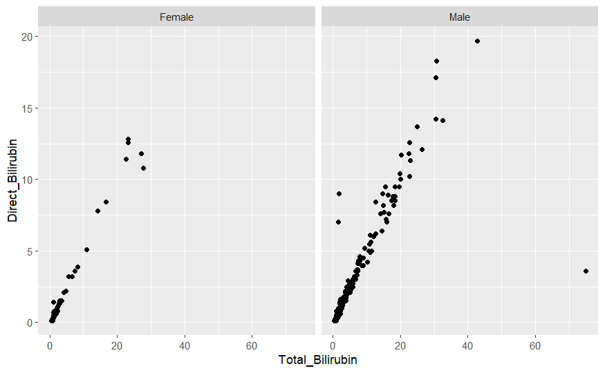

```r
ggplot(data, aes(x=Total_Bilirubin,y = Direct_Bilirubin))+
  geom_point()+facet_grid(.~Gender)
```

While both genders show a positive correlation between Total and Direct Bilirubin, males seem to have a wider range of Total Bilirubin values, and the distribution of their data points is different from that of females. The presence of outliers in both groups suggests unique cases or potential data anomalies.

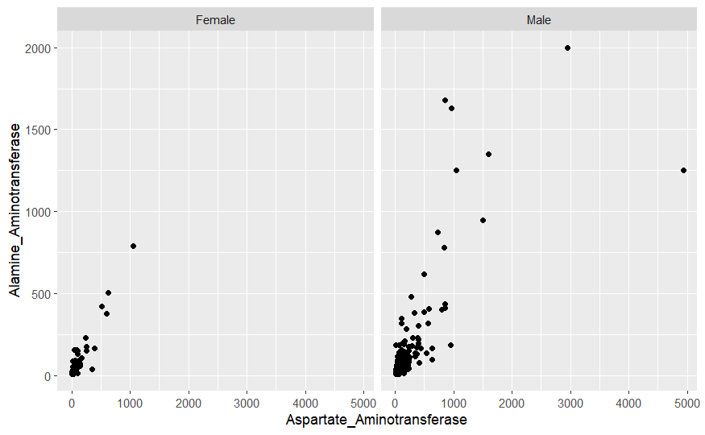

```r
ggplot(data, aes(x=Aspartate_Aminotransferase,y=Alamine_Aminotransferase))+
  geom_point()+facet_grid(.~Gender)
```

While both genders generally show low levels of the enzymes, males display a slightly broader distribution, with a few having significantly elevated enzyme levels. The scatter pattern, especially for males, suggests diverse conditions or factors affecting enzyme levels in different ways.

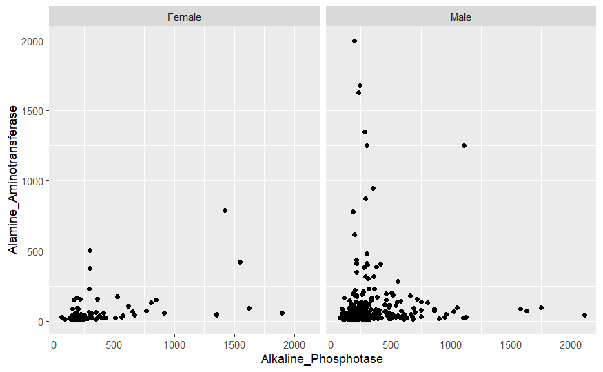

```r
ggplot(data, aes(x=Alkaline_Phosphotase ,y=Alamine_Aminotransferase))+
  geom_point()+facet_grid(.~Gender)
```

For both genders, most individuals have low levels of both enzymes. There are only a few instances in either gender where elevated levels of enzymes are observed. However, males seem to have a slightly more pronounced clustering in the lower levels of Alkaline Phosphatase compared to females. The data distribution indicates a general trend of lower enzyme levels for the majority, with rare exceptions of elevated levels.

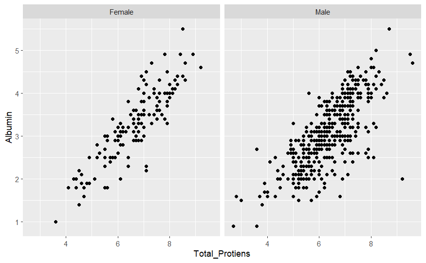

```r
ggplot(data, aes(x=Total_Protiens ,y=Albumin))+
  geom_point()+facet_grid(.~Gender)
```

Both the Total Proteins and Albumin are distributed across a range, with varying densities of data points across different regions of the plot for both genders.For both genders, there’s a positive correlation between Total Proteins and Albumin, meaning as the level of one increases, the other tends to increase as well. Males have a denser clustering of data points in the mid to high ranges, whereas females have a more spread-out distribution across the plot. Both plots, however, suggest that most individuals from both genders have mid-range levels of Total Proteins and Albumin.

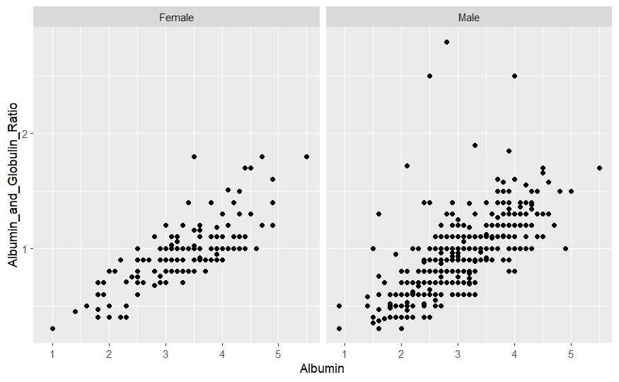

```r
ggplot(data, aes(x=Albumin ,y=Albumin_and_Globulin_Ratio))+
  geom_point()+facet_grid(.~Gender)
```

Both the Albumin and Albumin and Globulin Ratio are plotted across a range, and the densities of data points vary across different regions of the plot for both genders. For both genders, there’s a positive correlation between Albumin levels and the Albumin and Globulin Ratio. This means as the level of one metric increases, the other tends to increase as well. While both plots show a similar trend, males have a slightly more pronounced clustering in the mid-ranges compared to females. Both genders mostly exhibit mid-range values for the given metrics.

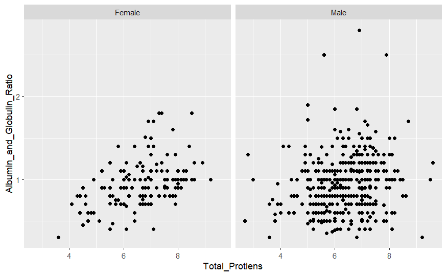

```r
ggplot(data, aes(x=Total_Protiens,y=Albumin_and_Globulin_Ratio))+
  geom_point()+facet_grid(.~Gender)
```

The Total Proteins are plotted against the Albumin and Globulin Ratio, giving insights into the concentration and distribution of data points for both genders. While both genders display a lack of a strong linear correlation between Total Proteins and the Albumin and Globulin Ratio, the distribution and density of data points differ slightly between the two. Males have a more dispersed distribution in the mid-ranges, while females have a more concentrated clustering in specific regions of the plot.

```r
numerical_data <- data[, sapply(data, is.numeric)]
correlation_matrix <- cor(numerical_data)
correlation_matrix
```

```
                                    Age Total_Bilirubin Direct_Bilirubin Alkaline_Phosphotase
Age                         1.000000000     0.011000374     6.784303e-03           0.07887835
Total_Bilirubin             0.011000374     1.000000000     8.744810e-01           0.20573917
Direct_Bilirubin            0.006784303     0.874480969     1.000000e+00           0.23400757
Alkaline_Phosphotase        0.078878350     0.205739173     2.340076e-01           1.00000000
Alamine_Aminotransferase   -0.087799162     0.213375493     2.331801e-01           0.12477671
Aspartate_Aminotransferase -0.020498946     0.237323055     2.570224e-01           0.16657999
Total_Protiens             -0.186248122    -0.007905923     3.270877e-05          -0.02706202
Albumin                    -0.264210935    -0.222086570    -2.284092e-01          -0.16341865
Albumin_and_Globulin_Ratio -0.216408346    -0.206267186    -2.001247e-01          -0.23416650
                           Alamine_Aminotransferase Aspartate_Aminotransferase Total_Protiens     Albumin
Age                                     -0.08779916                -0.02049895  -1.862481e-01 -0.26421094
Total_Bilirubin                          0.21337549                 0.23732305  -7.905923e-03 -0.22208657
Direct_Bilirubin                         0.23318008                 0.25702239   3.270877e-05 -0.22840915
Alkaline_Phosphotase                     0.12477671                 0.16657999  -2.706202e-02 -0.16341865
Alamine_Aminotransferase                 1.00000000                 0.79186215  -4.243210e-02 -0.02865750
Aspartate_Aminotransferase               0.79186215                 1.00000000  -2.575101e-02 -0.08491457
Total_Protiens                          -0.04243210                -0.02575101   1.000000e+00  0.78311217
Albumin                                 -0.02865750                -0.08491457   7.831122e-01  1.00000000
Albumin_and_Globulin_Ratio              -0.00237499                -0.07003983   2.348872e-01  0.68963234
                           Albumin_and_Globulin_Ratio
Age                                       -0.21640835
Total_Bilirubin                           -0.20626719
Direct_Bilirubin                          -0.20012469
Alkaline_Phosphotase                      -0.23416650
Alamine_Aminotransferase                  -0.00237499
Aspartate_Aminotransferase                -0.07003983
Total_Protiens                             0.23488718
Albumin                                    0.68963234
Albumin_and_Globulin_Ratio                 1.00000000
```

```r
d = data
str(d)
```

```
'data.frame':   579 obs. of  11 variables:
 $ Age                       : int  65 62 62 58 72 46 26 29 17 55 ...
 $ Gender                    : chr  "Female" "Male" "Male" "Male" ...
 $ Total_Bilirubin           : num  0.7 10.9 7.3 1 3.9 1.8 0.9 0.9 0.9 0.7 ...
 $ Direct_Bilirubin          : num  0.1 5.5 4.1 0.4 2 0.7 0.2 0.3 0.3 0.2 ...
 $ Alkaline_Phosphotase      : int  187 699 490 182 195 208 154 202 202 290 ...
 $ Alamine_Aminotransferase  : int  16 64 60 14 27 19 16 14 22 53 ...
 $ Aspartate_Aminotransferase: int  18 100 68 20 59 14 12 11 19 58 ...
 $ Total_Protiens            : num  6.8 7.5 7 6.8 7.3 7.6 7 6.7 7.4 6.8 ...
 $ Albumin                   : num  3.3 3.2 3.3 3.4 2.4 4.4 3.5 3.6 4.1 3.4 ...
 $ Albumin_and_Globulin_Ratio: num  0.9 0.74 0.89 1 0.4 1.3 1 1.1 1.2 1 ...
 $ Target                    : Factor w/ 2 levels "Class0","Class1": 2 2 2 2 2 2 2 2 1 2 ...
 - attr(*, "na.action")= 'omit' Named int [1:4] 210 242 254 313
  ..- attr(*, "names")= chr [1:4] "210" "242" "254" "313"
```

```r
# library(ROSE)
#
# d <- ovun.sample(Target~., data = d, method = "both", p = 0.6, seed = 222, N = 583)$data
#
# table((d$Target))
```

```r
#Splitting the Data in Test and Train.
set.seed(123)
sample_indices <- createDataPartition(d$Target, p = 0.7 , list = FALSE)
train_data <- d[sample_indices, ]
test_data <- d[-sample_indices, ]
```

## Logistic Regression.

```r
#Fitting Logistic Regression model.
model <- glm(Target ~ ., data = train_data, family = binomial())
summary(model)
```

```
Call:
glm(formula = Target ~ ., family = binomial(), data = train_data)

Coefficients:
                             Estimate Std. Error z value Pr(>|z|)
(Intercept)                -3.3097536  1.7511826  -1.890   0.0588 .
Age                         0.0135804  0.0077013   1.763   0.0778 .
GenderMale                  0.0458705  0.2767969   0.166   0.8684
Total_Bilirubin             0.0519806  0.2774034   0.187   0.8514
Direct_Bilirubin            0.3217718  0.5367192   0.600   0.5488
Alkaline_Phosphotase        0.0005561  0.0009406   0.591   0.5544
Alamine_Aminotransferase    0.0134961  0.0064695   2.086   0.0370 *
Aspartate_Aminotransferase  0.0012205  0.0036244   0.337   0.7363
Total_Protiens              1.0391063  0.5228067   1.988   0.0469 *
Albumin                    -1.8561056  1.0243598  -1.812   0.0700 .
Albumin_and_Globulin_Ratio  1.6931074  1.5319988   1.105   0.2691
---
Signif. codes:  0 ‘***’ 0.001 ‘**’ 0.01 ‘*’ 0.05 ‘.’ 0.1 ‘ ’ 1

(Dispersion parameter for binomial family taken to be 1)

    Null deviance: 485.79  on 405  degrees of freedom
Residual deviance: 404.59  on 395  degrees of freedom
AIC: 426.59

Number of Fisher Scoring iterations: 8
```

```r
# Making predictions
predictions <- predict(model, newdata = test_data, type = "response")

# Convert probabilities to binary class (adjust based on your factor levels)
# Make sure to use the same level as in your original Dataset variable
predicted_class <- ifelse(predictions > 0.5, "Class1", "Class0")  # Adjust "1" and "0" based on your factor levels
predicted_class <- factor(predicted_class, levels = levels(test_data$Target))

# Confusion Matrix
model_cm <- confusionMatrix(predicted_class, test_data$Target)

model_cm
```

```
Confusion Matrix and Statistics

          Reference
Prediction Class0 Class1
    Class0     10      8
    Class1     39    116

               Accuracy : 0.7283
                 95% CI : (0.6556, 0.7931)
    No Information Rate : 0.7168
    P-Value [Acc > NIR] : 0.4046

                  Kappa : 0.1726

 Mcnemar's Test P-Value : 1.209e-05

            Sensitivity : 0.2041
            Specificity : 0.9355
         Pos Pred Value : 0.5556
         Neg Pred Value : 0.7484
             Prevalence : 0.2832
         Detection Rate : 0.0578
   Detection Prevalence : 0.1040
      Balanced Accuracy : 0.5698

       'Positive' Class : Class0
```

While the model has decent overall accuracy and specificity, its sensitivity is low, meaning it does not identify Class0 cases well. It also does not perform significantly better than randomly guessing the most common class, as indicated by the P-Value [Acc > NIR] and the Kappa value. Additionally, the imbalance highlighted by Mcnemar’s test suggests the model is biased toward predicting Class1.

**Variable Selection using the Backward Step Selection Model.**

```r
step(model,direction="backward")
```

```
Start:  AIC=426.59
Target ~ Age + Gender + Total_Bilirubin + Direct_Bilirubin +
    Alkaline_Phosphotase + Alamine_Aminotransferase + Aspartate_Aminotransferase +
    Total_Protiens + Albumin + Albumin_and_Globulin_Ratio
```

```
                             Df Deviance    AIC
- Gender                      1   404.62 424.62
- Aspartate_Aminotransferase  1   404.71 424.71
- Total_Bilirubin             1   404.72 424.72
- Direct_Bilirubin            1   404.74 424.74
- Alkaline_Phosphotase        1   404.97 424.97
- Albumin_and_Globulin_Ratio  1   405.99 425.99
<none>                            404.59 426.59
- Age                         1   407.75 427.75
- Albumin                     1   408.68 428.68
- Total_Protiens              1   409.54 429.54
- Alamine_Aminotransferase    1   410.17 430.17
```

```
Step:  AIC=424.62
Target ~ Age + Total_Bilirubin + Direct_Bilirubin + Alkaline_Phosphotase +
    Alamine_Aminotransferase + Aspartate_Aminotransferase + Total_Protiens +
    Albumin + Albumin_and_Globulin_Ratio
```

```
                             Df Deviance    AIC
- Aspartate_Aminotransferase  1   404.74 422.74
- Total_Bilirubin             1   404.75 422.75
- Direct_Bilirubin            1   404.77 422.77
- Alkaline_Phosphotase        1   405.00 423.00
- Albumin_and_Globulin_Ratio  1   406.04 424.04
<none>                            404.62 424.62
- Age                         1   407.77 425.77
- Albumin                     1   408.75 426.75
- Total_Protiens              1   409.57 427.57
- Alamine_Aminotransferase    1   410.40 428.40
```

```
Step:  AIC=422.74
Target ~ Age + Total_Bilirubin + Direct_Bilirubin + Alkaline_Phosphotase +
    Alamine_Aminotransferase + Total_Protiens + Albumin + Albumin_and_Globulin_Ratio
```

```
                             Df Deviance    AIC
- Total_Bilirubin             1   404.87 420.87
- Direct_Bilirubin            1   404.88 420.88
- Alkaline_Phosphotase        1   405.12 421.12
- Albumin_and_Globulin_Ratio  1   406.24 422.24
<none>                            404.74 422.74
- Age                         1   407.83 423.83
- Albumin                     1   409.08 425.08
- Total_Protiens              1   409.85 425.85
- Alamine_Aminotransferase    1   422.96 438.96
```

```
Step:  AIC=420.87
Target ~ Age + Direct_Bilirubin + Alkaline_Phosphotase + Alamine_Aminotransferase +
    Total_Protiens + Albumin + Albumin_and_Globulin_Ratio
```

```
                             Df Deviance    AIC
- Alkaline_Phosphotase        1   405.26 419.26
- Albumin_and_Globulin_Ratio  1   406.35 420.35
<none>                            404.87 420.87
- Age                         1   407.96 421.96
- Albumin                     1   409.16 423.16
- Total_Protiens              1   409.93 423.93
- Direct_Bilirubin            1   416.60 430.60
- Alamine_Aminotransferase    1   423.03 437.03
```

```
Step:  AIC=419.26
Target ~ Age + Direct_Bilirubin + Alamine_Aminotransferase +
    Total_Protiens + Albumin + Albumin_and_Globulin_Ratio
```

```
                             Df Deviance    AIC
- Albumin_and_Globulin_Ratio  1   406.68 418.68
<none>                            405.26 419.26
- Age                         1   408.30 420.30
- Albumin                     1   409.69 421.69
- Total_Protiens              1   410.54 422.54
- Direct_Bilirubin            1   417.75 429.75
- Alamine_Aminotransferase    1   426.24 438.24
```

```
Step:  AIC=418.68
Target ~ Age + Direct_Bilirubin + Alamine_Aminotransferase +
    Total_Protiens + Albumin
```

```
                           Df Deviance    AIC
<none>                          406.68 418.68
- Age                       1   409.63 419.63
- Total_Protiens            1   413.67 423.67
- Albumin                   1   414.61 424.61
- Direct_Bilirubin          1   421.34 431.34
- Alamine_Aminotransferase  1   427.16 437.16

Call:  glm(formula = Target ~ Age + Direct_Bilirubin + Alamine_Aminotransferase +
    Total_Protiens + Albumin, family = binomial(), data = train_data)

Coefficients:
             (Intercept)                       Age          Direct_Bilirubin  Alamine_Aminotransferase
                -1.53631                   0.01313                   0.46742                   0.01559
          Total_Protiens                   Albumin
                 0.54246                  -0.84052

Degrees of Freedom: 405 Total (i.e. Null);  400 Residual
Null Deviance:      485.8
Residual Deviance: 406.7    AIC: 418.7
```

```r
# Fitting the Step-model
model2 = glm(formula = Target ~ Age + Direct_Bilirubin + Alamine_Aminotransferase +
    Total_Protiens + Albumin, family = binomial(), data = train_data)
```

```
Warning: glm.fit: fitted probabilities numerically 0 or 1 occurred
```

```r
summary(model2)
```

```
Call:
glm(formula = Target ~ Age + Direct_Bilirubin + Alamine_Aminotransferase +
    Total_Protiens + Albumin, family = binomial(), data = train_data)

Coefficients:
                          Estimate Std. Error z value Pr(>|z|)
(Intercept)              -1.536313   0.922962  -1.665  0.09600 .
Age                       0.013134   0.007692   1.707  0.08773 .
Direct_Bilirubin          0.467422   0.191017   2.447  0.01440 *
Alamine_Aminotransferase  0.015591   0.004798   3.250  0.00116 **
Total_Protiens            0.542461   0.208588   2.601  0.00931 **
Albumin                  -0.840524   0.303910  -2.766  0.00568 **
---
Signif. codes:  0 ‘***’ 0.001 ‘**’ 0.01 ‘*’ 0.05 ‘.’ 0.1 ‘ ’ 1

(Dispersion parameter for binomial family taken to be 1)

    Null deviance: 485.79  on 405  degrees of freedom
Residual deviance: 406.68  on 400  degrees of freedom
AIC: 418.68

Number of Fisher Scoring iterations: 7
```

The logistic regression analysis outputs a model indicating that out of the five predictors evaluated, Direct_Bilirubin, Alamine_Aminotransferase, Total_Proteins, and Albumin significantly affect the target variable, with Direct_Bilirubin and Alamine_Aminotransferase increasing the likelihood of the target event, while Albumin decreases it. Age shows a marginal increase in likelihood, though not at a conventional level of significance. The model’s adequacy is suggested by the reduction in deviance, yet the warning about probabilities being 0 or 1 suggests potential overfitting issues. With seven iterations of Fisher Scoring for convergence, the model’s fit is decent but needs cautious interpretation due to the extremes in predicted probabilities.

```r
# Making predictions
predictions2 <- predict(model2, newdata = test_data, type = "response")

# Make sure to use the same level as in your original Dataset variable
predicted_class <- ifelse(predictions2 > 0.5, "Class1", "Class0")
predicted_class <- factor(predicted_class, levels = levels(test_data$Target))

# Confusion Matrix
model2_cm <- confusionMatrix(predicted_class, test_data$Target)
model2_cm
```

```
Confusion Matrix and Statistics

          Reference
Prediction Class0 Class1
    Class0     10      7
    Class1     39    117

               Accuracy : 0.7341
                 95% CI : (0.6617, 0.7983)
    No Information Rate : 0.7168
    P-Value [Acc > NIR] : 0.3403

                  Kappa : 0.184

 Mcnemar's Test P-Value : 4.861e-06

            Sensitivity : 0.20408
            Specificity : 0.94355
         Pos Pred Value : 0.58824
         Neg Pred Value : 0.75000
             Prevalence : 0.28324
         Detection Rate : 0.05780
   Detection Prevalence : 0.09827
      Balanced Accuracy : 0.57382

       'Positive' Class : Class0
```

```r
anova(model,model2,test="Chisq")
```

```
Analysis of Deviance Table

Model 1: Target ~ Age + Gender + Total_Bilirubin + Direct_Bilirubin +
    Alkaline_Phosphotase + Alamine_Aminotransferase + Aspartate_Aminotransferase +
    Total_Protiens + Albumin + Albumin_and_Globulin_Ratio
Model 2: Target ~ Age + Direct_Bilirubin + Alamine_Aminotransferase +
    Total_Protiens + Albumin
  Resid. Df Resid. Dev Df Deviance Pr(>Chi)
1       395     404.59
2       400     406.68 -5  -2.0854   0.8372
```

**Plotting the ROC curve and Residual Plots for better understanding**

```r
library(ROCR)

# Assuming `model2` is your fitted model and `train_data$Target` is the true binary class label
fitted_probs <- predict(model2, type = "response")
observed <- train_data$Target

# Create the prediction object for ROC
prediction <- prediction(fitted_probs, observed)

# Create the ROC performance object
roc <- performance(prediction, "tpr", "fpr")

# Calculate the AUC
auc <- performance(prediction, "auc")
auc_value <- auc@y.values[[1]]  # Extract the AUC value

# Plot the ROC curve
plot(roc, main="ROC Curve")
# Add the AUC value to the plot
abline(a=0, b=1, lty=2, col="gray")
```

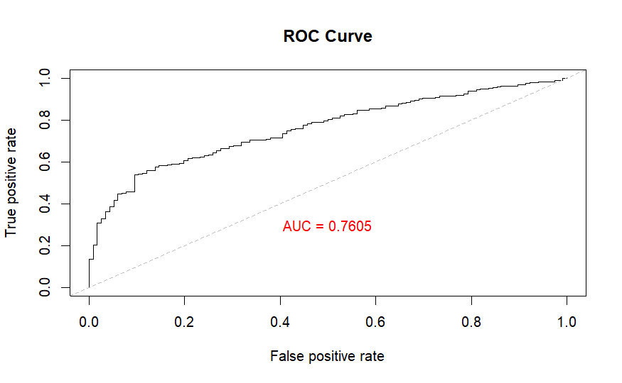

```r
text(0.5, 0.3, paste("AUC =", round(auc_value, 4)), col="red")
```

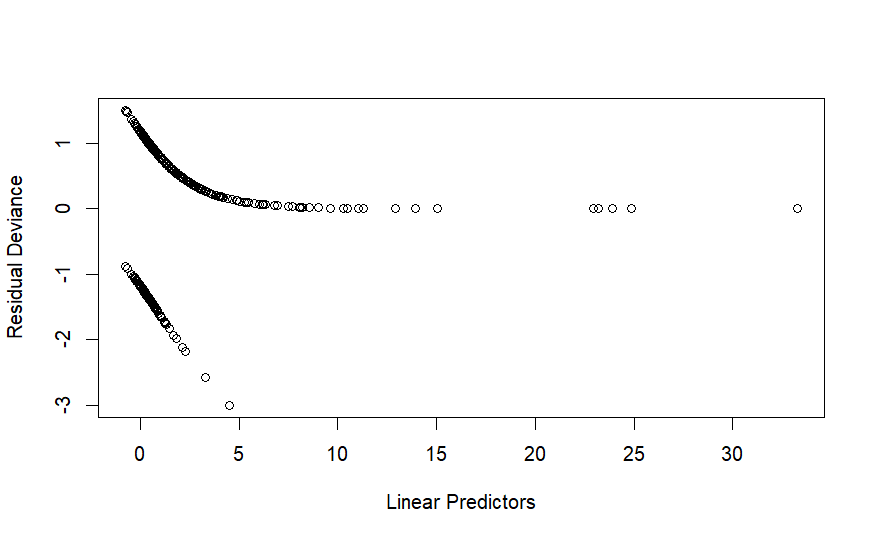

```r
# # Plot for Deviance Residuals
# dev_res <- residuals(model2, type = "deviance")
# plot(dev_res, ylab="Deviance Residuals", xlab="Index", main="Deviance Residuals Plot")
# abline(h = 0, col = "red")


residuals <- residuals(model2, type = "deviance")
plot_2 <- plot(model2$linear.predictors, residuals, xlab = "Linear Predictors", ylab = "Residual Deviance")
```

The ROC curve with an AUC of 0.7605 indicates that the binary classification model has good discriminatory ability. While it’s not perfect, the model is significantly better than random guessing at distinguishing between the two classes. The curve’s rapid initial ascent suggests that the model achieves a high true positive rate without incurring a high false positive rate at lower thresholds, which is desirable in a good classifier. Overall, this model shows solid performance, though there is potential for further optimization to improve its accuracy.

**Plotting Influence Plot**

|  | StudRes | Hat | CookD |
| --- | --- | --- | --- |
| 115 | -3.1006854 | 0.006438597 | 0.0981905538 |
| 116 | -2.6399177 | 0.012484282 | 0.0566864135 |
| 270 | 1.5467410 | 0.059243093 | 0.0233872543 |
| 573 | 0.2098368 | 0.068912654 | 0.0002841642 |

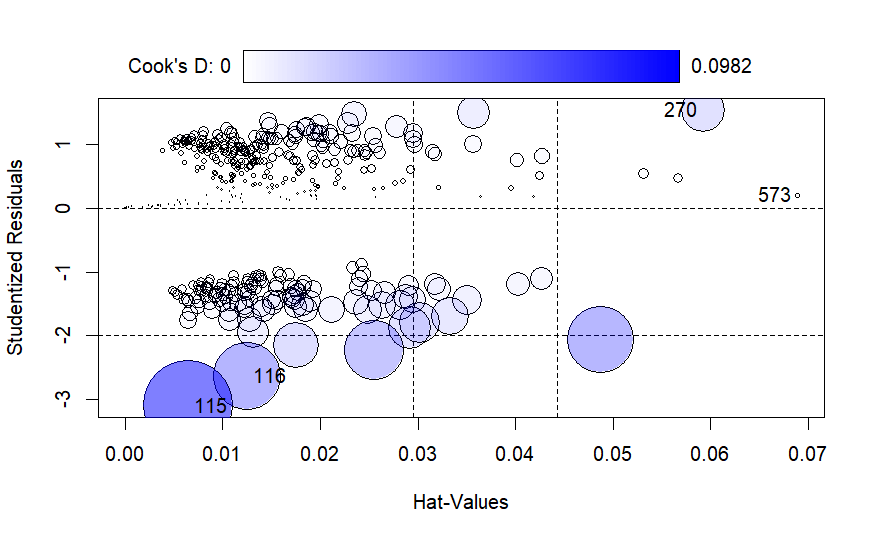

```r
influencePlot(model2)
```

```r
# Calculate Cook's distance
cooksD <- cooks.distance(model2)

# Threshold for identifying influential points (commonly used cutoff is 4/(n-k-1))
cutoff <- 4 / (nrow(train_data) - length(coef(model2)) - 1)

# Find the row numbers of the influential points
influential <- as.numeric(names(cooksD)[(cooksD > cutoff)])

# Create a new dataset without these points
cleaned_data <- train_data[-influential, ]

# Re-fit the model without the influential points
model_clean <- glm(formula = Target ~ Age + Direct_Bilirubin + Alamine_Aminotransferase +
    Total_Protiens + Albumin, family = binomial(), data = cleaned_data)
summary(model_clean)
```

```
Call:
glm(formula = Target ~ Age + Direct_Bilirubin + Alamine_Aminotransferase +
    Total_Protiens + Albumin, family = binomial(), data = cleaned_data)

Coefficients:
                          Estimate Std. Error z value Pr(>|z|)
(Intercept)              -1.782524   0.936401  -1.904  0.05696 .
Age                       0.013876   0.007795   1.780  0.07504 .
Direct_Bilirubin          0.457540   0.191998   2.383  0.01717 *
Alamine_Aminotransferase  0.015563   0.004778   3.257  0.00112 **
Total_Protiens            0.609370   0.213053   2.860  0.00423 **
Albumin                  -0.914491   0.309816  -2.952  0.00316 **
---
Signif. codes:  0 ‘***’ 0.001 ‘**’ 0.01 ‘*’ 0.05 ‘.’ 0.1 ‘ ’ 1

(Dispersion parameter for binomial family taken to be 1)

    Null deviance: 475.39  on 395  degrees of freedom
Residual deviance: 397.06  on 390  degrees of freedom
AIC: 409.06

Number of Fisher Scoring iterations: 7
```

```r
# Making predictions
predictions3 <- predict(model_clean, newdata = test_data, type = "response")

# Make sure to use the same level as in your original Dataset variable
predicted_class <- ifelse(predictions3 > 0.5, "Class1", "Class0")
predicted_class <- factor(predicted_class, levels = levels(test_data$Target))

# Confusion Matrix
model_clean_cm <- confusionMatrix(predicted_class, test_data$Target)
model_clean_cm
```

```
Confusion Matrix and Statistics

          Reference
Prediction Class0 Class1
    Class0     13     11
    Class1     36    113

               Accuracy : 0.7283
                 95% CI : (0.6556, 0.7931)
    No Information Rate : 0.7168
    P-Value [Acc > NIR] : 0.4045806

                  Kappa : 0.2088

 Mcnemar's Test P-Value : 0.0004639

            Sensitivity : 0.26531
            Specificity : 0.91129
         Pos Pred Value : 0.54167
         Neg Pred Value : 0.75839
             Prevalence : 0.28324
         Detection Rate : 0.07514
   Detection Prevalence : 0.13873
      Balanced Accuracy : 0.58830

       'Positive' Class : Class0
```

**Getting Performance Metrics**

```r
# Calculate Precision (Positive Predictive Value)
precision <- model_clean_cm$byClass['Pos Pred Value']

# Calculate Recall (same as Sensitivity)
recall <- model_clean_cm$byClass['Sensitivity']

# Calculate F1 Score
f1_score <- 2 * (precision * recall) / (precision + recall)

# Print the results
print(paste("Precision:", precision))
```

```
[1] "Precision: 0.541666666666667"
```

```r
print(paste("Recall:", recall))
```

```
[1] "Recall: 0.26530612244898"
```

```r
print(paste("F1 Score:", f1_score))
```

```
[1] "F1 Score: 0.356164383561644"
```

# SVM Model

```r
library(e1071)

tuneGrid <- expand.grid(C = c(0.1, 1, 5, 10))
# Fit SVM model with a linear kernel
svm_model <- svm(Target ~ ., data = train_data, method = "C-classification", kernel = "sigmoid", tuneGrid=tuneGrid)

# Make predictions using the SVM model
svm_pred <- predict(svm_model, newdata = test_data)

# Ensure that the true target variable is a factor and has the same levels as the model's target variable
test_data$Target <- factor(test_data$Target, levels = levels(train_data$Target))

# Create the confusion matrix
svm_cm <- confusionMatrix(svm_pred, test_data$Target)
svm_cm
```

```
Confusion Matrix and Statistics

          Reference
Prediction Class0 Class1
    Class0      1      0
    Class1     48    124

               Accuracy : 0.7225
                 95% CI : (0.6495, 0.7878)
    No Information Rate : 0.7168
    P-Value [Acc > NIR] : 0.4712

                  Kappa : 0.029

 Mcnemar's Test P-Value : 1.17e-11

            Sensitivity : 0.02041
            Specificity : 1.00000
         Pos Pred Value : 1.00000
         Neg Pred Value : 0.72093
             Prevalence : 0.28324
         Detection Rate : 0.00578
   Detection Prevalence : 0.00578
      Balanced Accuracy : 0.51020

       'Positive' Class : Class0
```

```r
# Create a trainControl object for cross-validation
dt_ctrl <- trainControl(method = "cv",       # Use k-fold cross-validation
                     number = 5,         # Number of folds (you can change this)
                     savePredictions = "final", # Save predictions for each fold
                     summaryFunction = twoClassSummary, # Summary function for binary classification
                     classProbs = TRUE,   # Return class probabilities
                     sampling = "down",
                     verboseIter = TRUE)  # Print training iterations

# Define the control parameters for the rpart model
#rpart_ctrl <- rpart.control(minsplit = 20, minbucket = 10, maxdepth = 5, cp = 0.001)


# Specify the tuning grid for the decision tree, focusing on the cp parameter
#grid <- expand.grid(.cp = seq(0.001, 0.1, by = 0.001))

# Train the decision tree model using the same CV control object
set.seed(123) # For reproducibility
model_dt <- train(Target ~ .,              # Model formula
                  data = train_data,       # Dataset
                  method = "rpart",        # Use recursive partitioning (decision tree)
                  trControl = dt_ctrl,        # Use the existing CV control object
                  #tuneGrid = grid,         # Tuning Grid
                  metric = "ROC",          # Optimization metric: ROC curve
                  preProcess = c("center", "scale")) # Pre-processing steps if needed
                  #control = rpart_ctrl) # Decision tree control parameters

# Predict using the decision tree model
predictions <- predict(model_dt, newdata = test_data)

# Create the confusion matrix
dt_cm <- confusionMatrix(predictions, test_data$Target)

# Print the confusion matrix
print(dt_cm)
```

```
Confusion Matrix and Statistics

          Reference
Prediction Class0 Class1
    Class0     34     51
    Class1     15     73

               Accuracy : 0.6185
                 95% CI : (0.5417, 0.6912)
    No Information Rate : 0.7168
    P-Value [Acc > NIR] : 0.998

                  Kappa : 0.2312

 Mcnemar's Test P-Value : 1.646e-05

            Sensitivity : 0.6939
            Specificity : 0.5887
         Pos Pred Value : 0.4000
         Neg Pred Value : 0.8295
             Prevalence : 0.2832
         Detection Rate : 0.1965
   Detection Prevalence : 0.4913
      Balanced Accuracy : 0.6413

       'Positive' Class : Class0
```

```r
var_imp <- varImp(model_dt, scale= FALSE)
var_imp
```

```
rpart variable importance
```

|  | Overall |
| --- | --- |
| Alkaline_Phosphotase | 35.012466 |
| Aspartate_Aminotransferase | 26.314661 |
| Alamine_Aminotransferase | 23.990045 |
| Total_Bilirubin | 22.435710 |
| Age | 20.580379 |
| Direct_Bilirubin | 17.477470 |
| Albumin_and_Globulin_Ratio | 10.079874 |
| Total_Protiens | 7.010863 |
| Albumin | 3.021821 |
| GenderMale | 0.000000 |

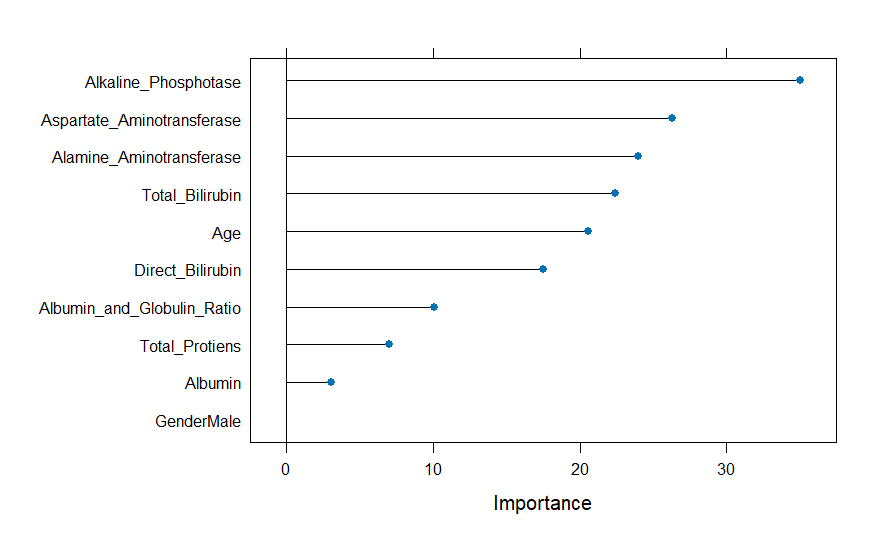

```r
plot(var_imp)
```

```r
library(dplyr)
new_data_train = select(train_data,c("Alkaline_Phosphotase","Aspartate_Aminotransferase","Alamine_Aminotransferase","Total_Bilirubin","Age","Target"))


new_data_test = select(test_data,c("Alkaline_Phosphotase","Aspartate_Aminotransferase","Alamine_Aminotransferase","Total_Bilirubin","Age","Target"))
```

```r
new_model_dt <- train(Target ~ .,              # Model formula
                  data = new_data_train,       # Dataset
                  method = "rpart",        # Use recursive partitioning (decision tree)
                  trControl = dt_ctrl,        # Use the existing CV control object
                  #tuneGrid = grid,         # Tuning Grid
                  metric = "ROC",          # Optimization metric: ROC curve
                  preProcess = c("center", "scale"))
```

```r
predictions <- predict(new_model_dt, newdata = new_data_test)

# Create the confusion matrix
dt_cm <- confusionMatrix(predictions, test_data$Target)

# Print the confusion matrix
print(dt_cm)
```

```
Confusion Matrix and Statistics

          Reference
Prediction Class0 Class1
    Class0     33     35
    Class1     16     89

               Accuracy : 0.7052
                 95% CI : (0.6312, 0.772)
    No Information Rate : 0.7168
    P-Value [Acc > NIR] : 0.66702

                  Kappa : 0.3502

 Mcnemar's Test P-Value : 0.01172

            Sensitivity : 0.6735
            Specificity : 0.7177
         Pos Pred Value : 0.4853
         Neg Pred Value : 0.8476
             Prevalence : 0.2832
         Detection Rate : 0.1908
   Detection Prevalence : 0.3931
      Balanced Accuracy : 0.6956

       'Positive' Class : Class0
```